# TEST1_R

John Horton

October 13, 2015

Test 1 R

Setup:

```r
#Load required packages
require(ggplot2)
require(grid)
require(plyr)
```

Question 1:

This function takes a dataframe from the user and adds to it a logical column with a TRUE/FALSE entry for each row in the dataframe, with some given percentage of those entries being TRUE and the rest being FALSE. I used this mechanism of randomly assigning TRUE/FALSE to each entry in diamonds as no direction was given as to which entries should receive TRUE and which should receive FALSE, only a ratio of TRUE entries to FALSE entries. As entries are randomly assigned, the TRUE/FALSE ratio will never be exact, but will be quite close to the given ratio as diamonds contains some 50,000+ entries.

Parameters: - dataFrame: the dataframe passed by the user; the new logical column will be added to that dataframe

Return: - returnFrame: the user’s dataframe, with the logical column added on

```r
addLogical <- function(dataFrame){
  #Here we generate a vector of random values between 0 and 1, generating a random value for each row in the user's dataframe
  randVec <- runif(nrow(diamonds),0.0,1.0)
  #We initialize logicVec as an empty vector
  logicVec <- c()
  #The variable pctTrue represents the percentage of TRUE entries in the new logical column of the user's dataframe; we use 0.4375 as per Professor G's posted interpretation of the question
  pctTrue <- 0.4375
  #We loop through each value in randVec so we may assign corresponding values to logicVec
  for(i in 1:length(randVec)){
    #If the value randVec[i] is less than pctTrue, we add a TRUE to logicVec; otherwise, we add a FALSE to logicVec
    if(randVec[i] <= pctTrue){
      logicVec[i] <- TRUE
    }
    else{
      logicVec[i] <- FALSE
    }
  }
  #We initialize the return dataframe and add the logical column
  returnFrame <- data.frame(dataFrame)
  returnFrame$logical <- logicVec
  return(returnFrame)
}

#Tests the function
logFrame <- addLogical(diamonds)
#print(testFrame)

#To quickly test the function and to avoid printing the full dataframe, we may look at the dimensions of the new dataframe to make sure they check out
print(dim(diamonds)[1])
```

```
## [1] 53940
```

```r
print(dim(diamonds)[2])
```

```
## [1] 10
```

```r
print(dim(logFrame)[1])
```

```
## [1] 53940
```

```r
print(dim(logFrame)[2])
```

```
## [1] 11
```

Question 2:

This function takes a dataframe from the user and returns a dataframe containing only the columns of the original dataframe that represent factors or logical variables.

Parameters: - dataFrame: the dataframe passed by the user

Return: - returnFrame: a dataframe containing only the columns of the user’s dataframe that represent factors or logical variables

```r
Extract_Fac <- function(dataFrame){
  #We use the sapply function on dataFrame to isolate only those columns in dataFrame for which 'is.factor' returns 'TRUE'
  facDataFrame <- dataFrame[sapply(dataFrame,is.factor)]
  #We use the sapply function on dataFrame to isolate only those columns in dataFRame for which 'is.logical' returns 'FALSE'
  logDataFrame <- dataFrame[sapply(dataFrame,is.logical)]
  #We merge facDataFrame and logDataFrame so that our returnFrame contains all factor columns and all logical columns
  returnFrame <- data.frame(facDataFrame,logDataFrame)
  return(returnFrame)
}

#Tests the function
testFac = Extract_Fac(logFrame)
#print(logFrame)
#print(testFac)
```

Question 3:

This function takes a dataframe from the user and returns a list of bar plots for each of the columns in the user’s dataframe that represent factors or logical variables.

Parameters: - dataFrame: the dataframe passed by the user

Return: - facPlots: a list of bar plots for each column in dataFrame that represents a factor or a logical variable

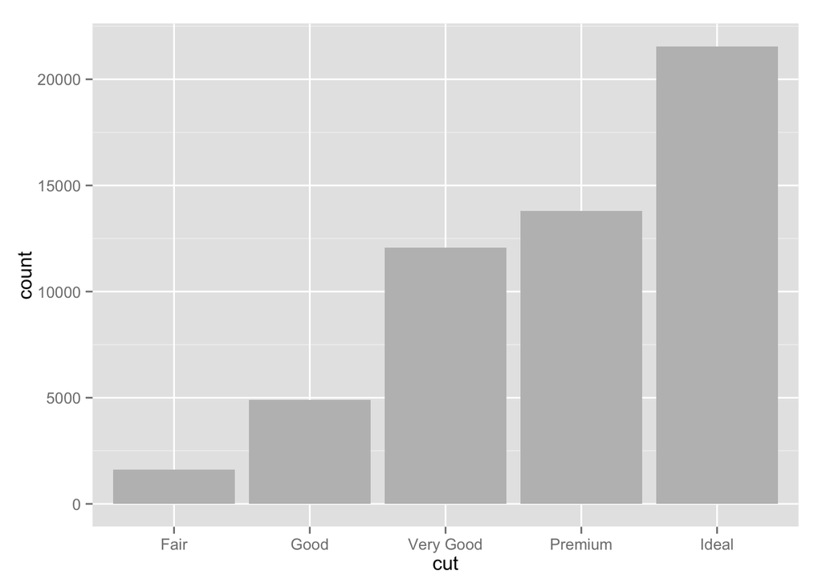

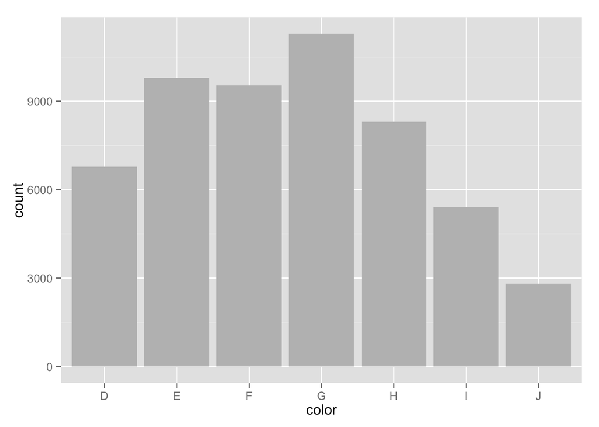

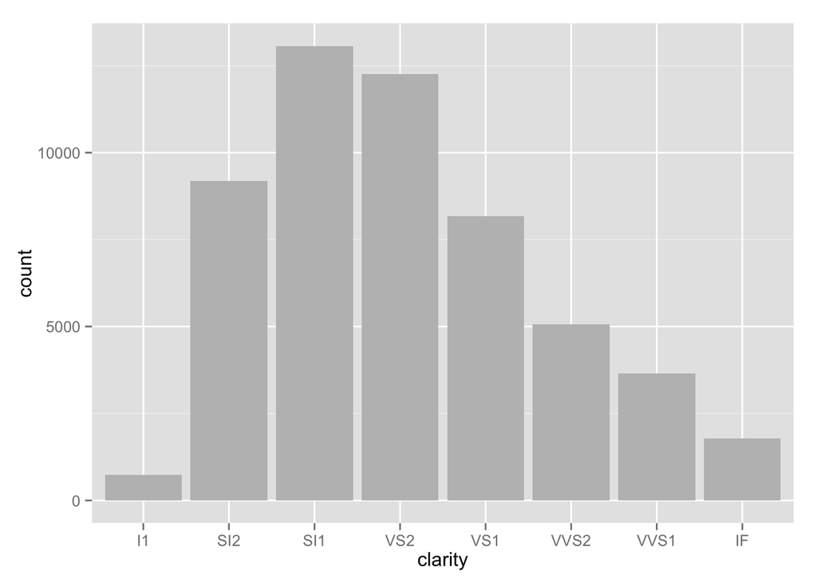

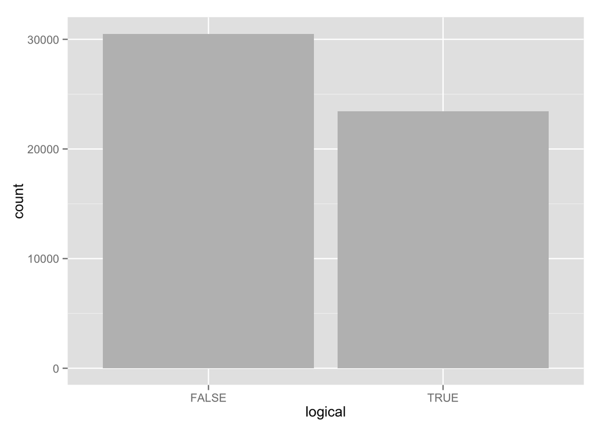

```r
Factor_Plot <- function(dataFrame){
  #We first extract all of the factor columns and logical columns from dataFrame
  dataFrame <- Extract_Fac(dataFrame)
  #We initialize facPlots as an empty list
  facPlots <- list()
  #We loop through each of the factor columns and logical columns in dataFrame
  for(i in 1:ncol(dataFrame)){
    #xLabel stores the name of the column to be plotted, so we may avoid calling a function inside our aes call below
    xLabel <- colnames(dataFrame)[i]
    #We call ggplot and geom_bar to produce a bar plot for each factor column and logical column in dataFrame
    #Each such plot is then added to facPlots so that all plots may be returned
    facPlots[[i]] <- ggplot(dataFrame,aes_string(xLabel))+geom_bar(fill="grey")
  }
  return(facPlots)
}

#Tests the function
testPlots <- Factor_Plot(logFrame)
print(testPlots)
```

Question 4:

This function takes a dataframe from the user and returns a list of frequency tables for each of the columns in the user’s dataframe that represent factors or logical variables.

Parameters: - dataFrame: the dataframe passed by the user

Return: - facTables: a list of frequency tables for each column in dataFrame that represents a factor or a logical variable

```r
Factor_Table <- function(dataFrame){
  #We first extract all of the factor columns and logical columns from dataFrame
  dataFrame <- Extract_Fac(dataFrame)
  #We initialize facTables as an empty list
  facTables <- list()
  #We loop through each of the factor columns and logical columns in dataFrame
  for(i in 1:ncol(dataFrame)){
    #varName stores the name of the column for which we are taking the next frequency table, so we may avoid calling a function inside our count call below
    varName <- colnames(dataFrame)[i]
    #We use the count function from the plyr package to construct frequency tables for each factor column and logical column in dataFrame
    #The count function returns the frequency tables as dataframes, each of which is stored in facTables so that all tables may be returned
    facTables[[i]] <- count(dataFrame,varName)
  }
  return(facTables)
}

#Tests the function
testTables <- Factor_Table(logFrame)
print(testTables)
```

```
## [[1]]
##         cut  freq
## 1      Fair  1610
## 2      Good  4906
## 3 Very Good 12082
## 4   Premium 13791
## 5     Ideal 21551
##
## [[2]]
##   color  freq
## 1     D  6775
## 2     E  9797
## 3     F  9542
## 4     G 11292
## 5     H  8304
## 6     I  5422
## 7     J  2808
##
## [[3]]
##   clarity  freq
## 1      I1   741
## 2     SI2  9194
## 3     SI1 13065
## 4     VS2 12258
## 5     VS1  8171
## 6    VVS2  5066
## 7    VVS1  3655
## 8      IF  1790
##
## [[4]]
##   logical  freq
## 1   FALSE 30497
## 2    TRUE 23443
```